# ggplot2

Nicholas A. C. Marino

nac.marino@gmail.com

github.com/nacmarino/introducaoR

# ggplot2

Este é um dos pacotes gráficos mais utilizados na linguagem R (diz-se que mais até que o `base` e `lattice`). Ele foi escrito por Hadley Wickham (cientista chefe do RStudio), quando ainda era um estudante de pós-graduação, e representa a implementação do *The Grammar of Graphics*, idéia desenvolvida por Leland Wilkinson.

> “Resumidamente, a gramática nos diz que um gráfico deve ser mapeado (**mapping**) a partir dos dados (**data**), de acordo com a aparência (**aesthetic**) (color, formato, tamanho) de objetos geométricos (**geometric**) (pontos, linhas, barras). A figura também pode conter transformações estatísticas dos dados, sendo desenhada a partir de um sistema específico de coordenadas.” (Do livro “*ggplot2*”)

Para compreender o porquê da ideia ser chamada de Gramática dos Gráficos, basta fazer um paralelo com a nossa gramática (licença poética permitida). Para criar um gráfico existe:  
* um sujeito, que são as variáveis que queremos colocar no gráfico (*data*, *aesthetics*);  
* um ou mais verbos, que representa de que forma o sujeito será apresentado (*geometries*, *facets*);  
* um ou mais adjetivo, que descreve características do sujeito (*color*, *fill*, *shape*, *alpha*).

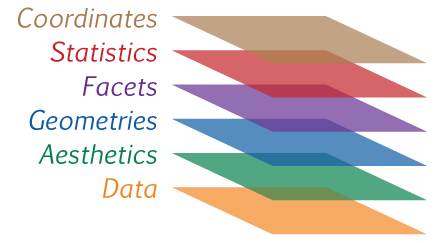

Ou seja, a principal ideia por traz da Gramática dos Gráficos e da implementação deste pacote é reduzir a distância entre a mente e a página, a ideia e a criação: você desenha, adicionando e modificando as camadas durante o processo. Isto traz algumas vantagens:  
* Não é preciso realizar todo o desenho em um único objeto (ao contrário do `lattice`);  
* Uma vez que você tenha adicionado uma entidade ao gráfico, você pode alterar ela posteriormente (ao contrário do `base`);  
* Gráficos complexos, com comandos simples e intuitivos (ao contrário do `lattice` e `base`).

Você pode carregar a Gramática dos Gráficos pelo pacote `ggplot2`, ou carregar as suas funções através do pacote `tidyverse`.

```r
library(tidyverse)
```

Para esta primeira parte da aula, vamos usar um dos dados que utilizamos na aula sobre manipulação de dados: `gapminder`.

```r
# carregando pacote
library(gapminder)
# conjunto de dados
gapminder
```

```
## # A tibble: 1,704 × 6
##        country continent  year lifeExp      pop gdpPercap
##         <fctr>    <fctr> <int>   <dbl>    <int>     <dbl>
## 1  Afghanistan      Asia  1952  28.801  8425333  779.4453
## 2  Afghanistan      Asia  1957  30.332  9240934  820.8530
## 3  Afghanistan      Asia  1962  31.997 10267083  853.1007
## 4  Afghanistan      Asia  1967  34.020 11537966  836.1971
## 5  Afghanistan      Asia  1972  36.088 13079460  739.9811
## 6  Afghanistan      Asia  1977  38.438 14880372  786.1134
## 7  Afghanistan      Asia  1982  39.854 12881816  978.0114
## 8  Afghanistan      Asia  1987  40.822 13867957  852.3959
## 9  Afghanistan      Asia  1992  41.674 16317921  649.3414
## 10 Afghanistan      Asia  1997  41.763 22227415  635.3414
## # ... with 1,694 more rows
```

A função mais básica dentro do `ggplot2` é a função `qplot` (“*quick plot*”). Ela oferece a forma mais simples e rápida de empregar a gramática dos gráficos, sem atentar muito à qualidade visual final do mesmo.

```r
# "..." são os aesthetics (size, shape, color, fill)
args(qplot)
```

```
## function (x, y = NULL, ..., data, facets = NULL, margins = FALSE,
##     geom = "auto", xlim = c(NA, NA), ylim = c(NA, NA), log = "",
##     main = NULL, xlab = deparse(substitute(x)), ylab = deparse(substitute(y)),
##     asp = NA, stat = NULL, position = NULL)
## NULL
```

Para começar, vamos plotar uma relação entre o tamanho da população e o GDP com o conjunto de dados do `gapminder`.

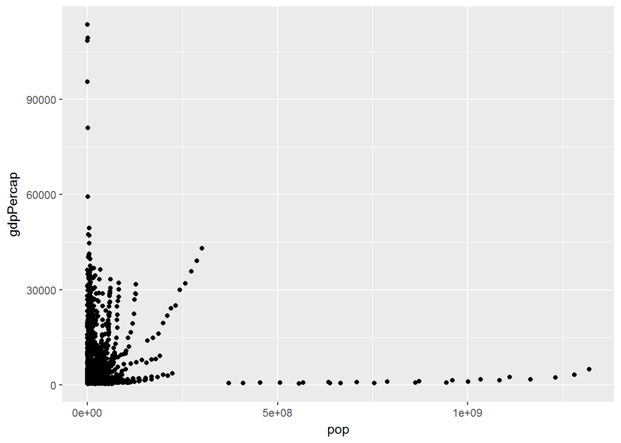

```r
qplot(x =  pop, y = gdpPercap, data = gapminder)
```

Podemos adicionar elementos gráficos à figura que criamos, baseado em alguma informação sobre os dados. Vamos fazer com que cada ponto tenha uma cor diferente de acordo com a expectativa de vida e um formato de símbolo diferente de acordo com o continente.

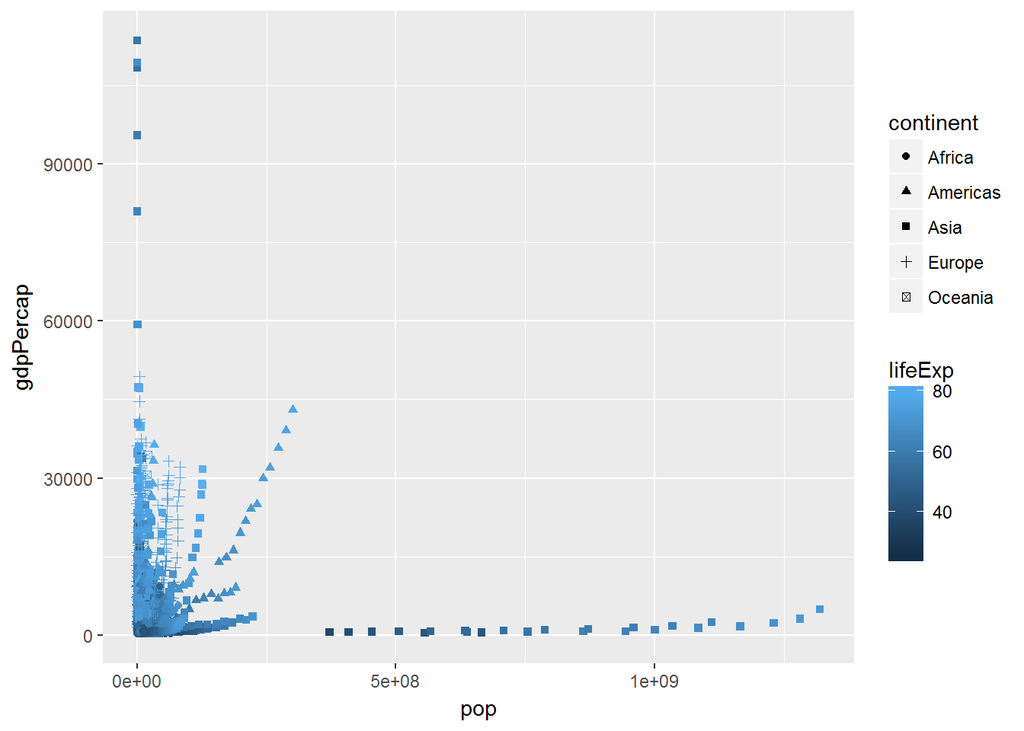

```r
qplot(x =  pop, y = gdpPercap, shape = continent, colour = lifeExp, data = gapminder)
```

Como o gráfico está ruim de ver, por conta do *range* de variabilidade existente, podemos logaritimizar os dois eixos.

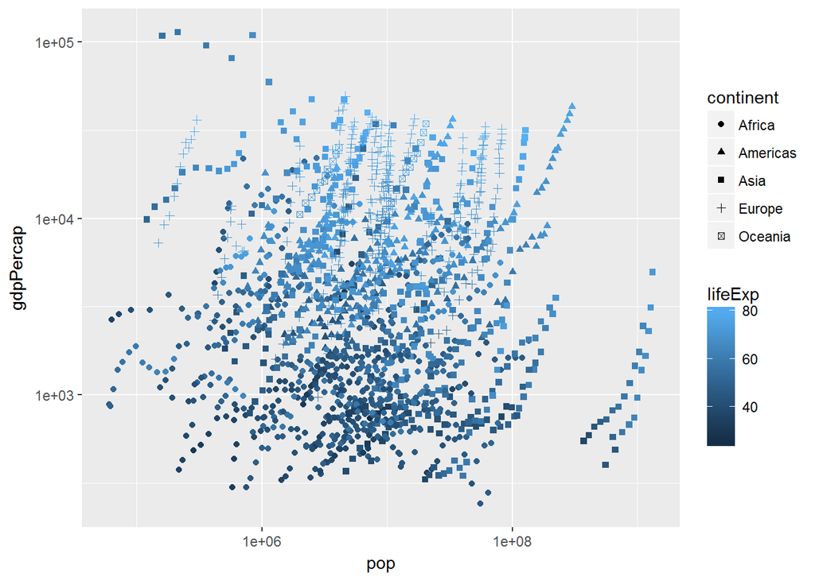

```r
qplot(x =  pop, y = gdpPercap, shape = continent, colour = lifeExp, data = gapminder, log = "xy")
```

Agora embaralhou tudo! Uma forma de resolver isso é plotar uma figura diferente para cada continente, por exemplo. Podemos fazer isso colocando cada continente em um painel distinto:

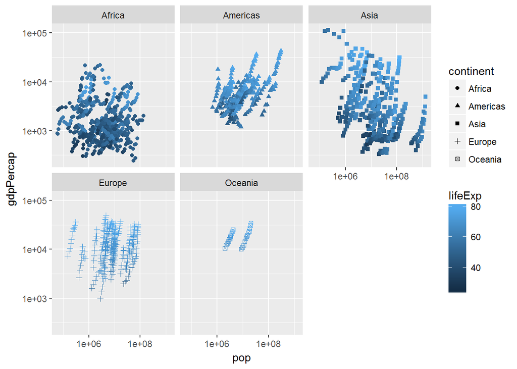

```r
qplot(x =  pop, y = gdpPercap, shape = continent, colour = lifeExp, data = gapminder, log = "xy", facets = ~ continent)
```

Como podemos ver, os dados parecem mostrar algum tipo de tendência, que poderia ser melhor retratada por uma regressão.

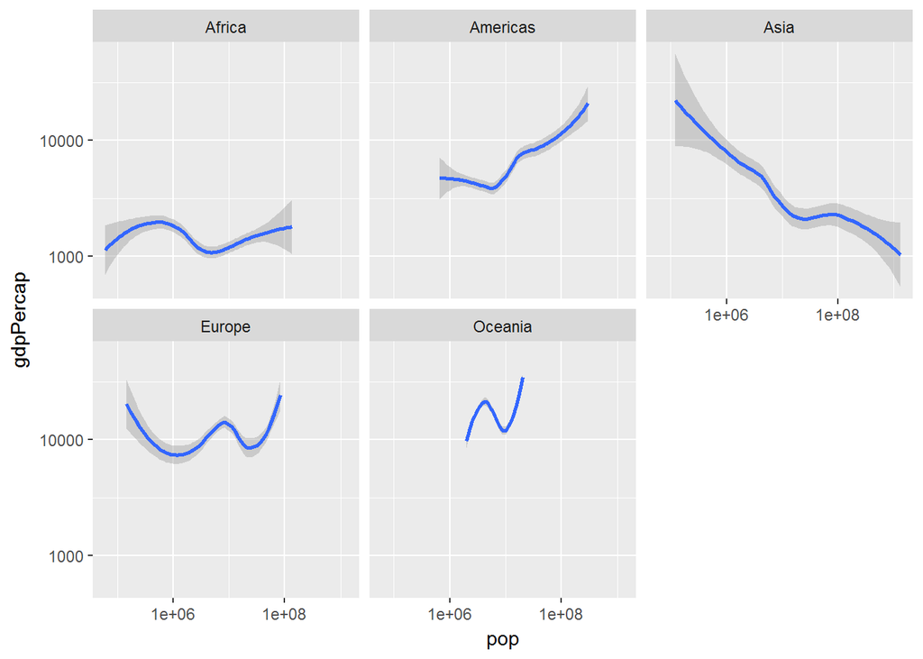

```r
qplot(x =  pop, y = gdpPercap, shape = continent, colour = lifeExp, data = gapminder, log = "xy", facets = ~ continent, geom = "smooth")
```

Note então que podemos criar tipos diferentes de gráficos modificando o argumento `geom`. Poderíamos, por exemplo, criar um gráfico de boxplot para mostrar as diferenças no GDP entre continentes:

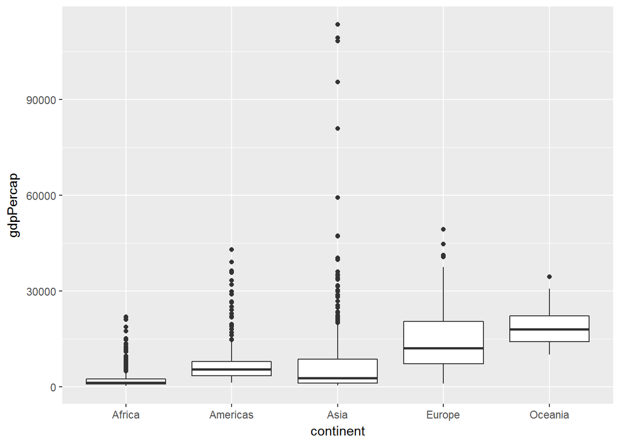

```r
qplot(x = continent, y = gdpPercap, data = gapminder, geom = "boxplot")
```

E podemos adicionar outras customizações a esse gráfico:

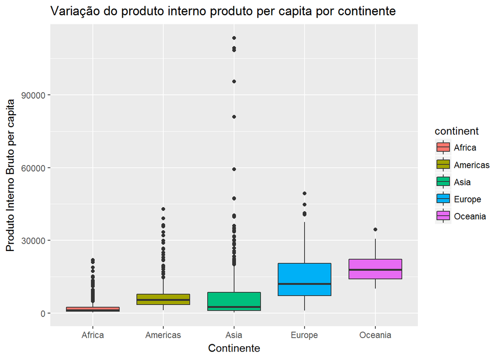

```r
qplot(x = continent, y = gdpPercap, data = gapminder, geom = "boxplot", fill = continent,
      xlab = "Continente", ylab = "Produto Interno Bruto per capita",
      main = "Variação do produto interno produto per capita por continente")
```

Apesar da similaridade inicial com algumas características função `plot`, você pode ver que o uso do `ggplot2` é bem mais intuitivo do que aquele do `plot`. Entretanto, a função `qplot` oferece uma baixa capacidade de customização do gráfico (por exemplo, não temos como remover este fundo cinza horroroso). Apesar disso, esta é a intenção principal desta função, pois ela foi feita para produzir gráficos rápidos e informativos para a exploração de dados.

Veremos a seguir como usar todo o potencial e funcionalidade do `ggplot2`.